# Risk Factor Analysis

## Outcome Variable

**Outcome Variable:** ever_swasted

## Predictor Variables

**Intervention Variable:** gagebrth

**Adjustment Set:**

- arm
- sex
- W_mage
- meducyrs
- feducyrs
- hhwealth_quart
- single
- brthmon
- W_parity
- delta_W_mage
- delta_meducyrs
- delta_feducyrs
- delta_hhwealth_quart
- delta_single
- delta_brthmon
- delta_W_parity

## Stratifying Variables

The analysis was stratified on these variable(s):

- agecat
- studyid
- country

## Data Summary

| agecat | studyid | country | gagebrth | ever_swasted | n_cell | n |
| --- | --- | --- | --- | --- | --- | --- |
| 0-24 months (no birth wast) | ki1000108-CMC-V-BCS-2002 | INDIA | Full or late term | 0 | 183 | 348 |
| 0-24 months (no birth wast) | ki1000108-CMC-V-BCS-2002 | INDIA | Full or late term | 1 | 30 | 348 |
| 0-24 months (no birth wast) | ki1000108-CMC-V-BCS-2002 | INDIA | Preterm | 0 | 42 | 348 |
| 0-24 months (no birth wast) | ki1000108-CMC-V-BCS-2002 | INDIA | Preterm | 1 | 10 | 348 |
| 0-24 months (no birth wast) | ki1000108-CMC-V-BCS-2002 | INDIA | Early term | 0 | 71 | 348 |
| 0-24 months (no birth wast) | ki1000108-CMC-V-BCS-2002 | INDIA | Early term | 1 | 12 | 348 |
| 0-24 months (no birth wast) | ki1000108-IRC | INDIA | Full or late term | 0 | 206 | 389 |
| 0-24 months (no birth wast) | ki1000108-IRC | INDIA | Full or late term | 1 | 43 | 389 |
| 0-24 months (no birth wast) | ki1000108-IRC | INDIA | Preterm | 0 | 34 | 389 |
| 0-24 months (no birth wast) | ki1000108-IRC | INDIA | Preterm | 1 | 8 | 389 |
| 0-24 months (no birth wast) | ki1000108-IRC | INDIA | Early term | 0 | 74 | 389 |
| 0-24 months (no birth wast) | ki1000108-IRC | INDIA | Early term | 1 | 24 | 389 |
| 0-24 months (no birth wast) | ki1000109-EE | PAKISTAN | Full or late term | 0 | 24 | 377 |
| 0-24 months (no birth wast) | ki1000109-EE | PAKISTAN | Full or late term | 1 | 1 | 377 |
| 0-24 months (no birth wast) | ki1000109-EE | PAKISTAN | Preterm | 0 | 205 | 377 |
| 0-24 months (no birth wast) | ki1000109-EE | PAKISTAN | Preterm | 1 | 38 | 377 |
| 0-24 months (no birth wast) | ki1000109-EE | PAKISTAN | Early term | 0 | 97 | 377 |
| 0-24 months (no birth wast) | ki1000109-EE | PAKISTAN | Early term | 1 | 12 | 377 |
| 0-24 months (no birth wast) | ki1000304b-SAS-CompFeed | INDIA | Full or late term | 0 | 25 | 1487 |
| 0-24 months (no birth wast) | ki1000304b-SAS-CompFeed | INDIA | Full or late term | 1 | 3 | 1487 |
| 0-24 months (no birth wast) | ki1000304b-SAS-CompFeed | INDIA | Preterm | 0 | 1202 | 1487 |
| 0-24 months (no birth wast) | ki1000304b-SAS-CompFeed | INDIA | Preterm | 1 | 156 | 1487 |
| 0-24 months (no birth wast) | ki1000304b-SAS-CompFeed | INDIA | Early term | 0 | 89 | 1487 |
| 0-24 months (no birth wast) | ki1000304b-SAS-CompFeed | INDIA | Early term | 1 | 12 | 1487 |
| 0-24 months (no birth wast) | ki1017093c-NIH-Crypto | BANGLADESH | Full or late term | 0 | 165 | 754 |
| 0-24 months (no birth wast) | ki1017093c-NIH-Crypto | BANGLADESH | Full or late term | 1 | 3 | 754 |
| 0-24 months (no birth wast) | ki1017093c-NIH-Crypto | BANGLADESH | Preterm | 0 | 250 | 754 |
| 0-24 months (no birth wast) | ki1017093c-NIH-Crypto | BANGLADESH | Preterm | 1 | 11 | 754 |
| 0-24 months (no birth wast) | ki1017093c-NIH-Crypto | BANGLADESH | Early term | 0 | 319 | 754 |
| 0-24 months (no birth wast) | ki1017093c-NIH-Crypto | BANGLADESH | Early term | 1 | 6 | 754 |

[output cut: 114 more lines]

The following strata were considered:

- agecat: 0-24 months (no birth wast), studyid: ki1000108-CMC-V-BCS-2002, country: INDIA
- agecat: 0-24 months (no birth wast), studyid: ki1000108-IRC, country: INDIA
- agecat: 0-24 months (no birth wast), studyid: ki1000109-EE, country: PAKISTAN
- agecat: 0-24 months (no birth wast), studyid: ki1000304b-SAS-CompFeed, country: INDIA
- agecat: 0-24 months (no birth wast), studyid: ki1017093c-NIH-Crypto, country: BANGLADESH
- agecat: 0-24 months (no birth wast), studyid: ki1066203-TanzaniaChild2, country: TANZANIA, UNITED REPUBLIC OF
- agecat: 0-24 months (no birth wast), studyid: ki1101329-Keneba, country: GAMBIA
- agecat: 0-24 months (no birth wast), studyid: ki1119695-PROBIT, country: BELARUS
- agecat: 0-24 months (no birth wast), studyid: ki1135781-COHORTS, country: GUATEMALA
- agecat: 0-24 months (no birth wast), studyid: ki1135781-COHORTS, country: INDIA
- agecat: 0-24 months (no birth wast), studyid: ki1135781-COHORTS, country: PHILIPPINES
- agecat: 0-24 months (no birth wast), studyid: kiGH5241-JiVitA-3, country: BANGLADESH
- agecat: 6-24 months, studyid: ki1000108-CMC-V-BCS-2002, country: INDIA
- agecat: 6-24 months, studyid: ki1000108-IRC, country: INDIA
- agecat: 6-24 months, studyid: ki1000109-EE, country: PAKISTAN
- agecat: 6-24 months, studyid: ki1000304b-SAS-CompFeed, country: INDIA
- agecat: 6-24 months, studyid: ki1017093c-NIH-Crypto, country: BANGLADESH
- agecat: 6-24 months, studyid: ki1066203-TanzaniaChild2, country: TANZANIA, UNITED REPUBLIC OF
- agecat: 6-24 months, studyid: ki1101329-Keneba, country: GAMBIA
- agecat: 6-24 months, studyid: ki1119695-PROBIT, country: BELARUS
- agecat: 6-24 months, studyid: ki1135781-COHORTS, country: GUATEMALA
- agecat: 6-24 months, studyid: ki1135781-COHORTS, country: INDIA
- agecat: 6-24 months, studyid: ki1135781-COHORTS, country: PHILIPPINES
- agecat: 6-24 months, studyid: kiGH5241-JiVitA-3, country: BANGLADESH

### Dropped Strata

Some strata were dropped due to rare outcomes:

- agecat: 0-24 months (no birth wast), studyid: ki1000109-EE, country: PAKISTAN
- agecat: 0-24 months (no birth wast), studyid: ki1000304b-SAS-CompFeed, country: INDIA
- agecat: 0-24 months (no birth wast), studyid: ki1017093c-NIH-Crypto, country: BANGLADESH
- agecat: 0-24 months (no birth wast), studyid: ki1135781-COHORTS, country: GUATEMALA
- agecat: 6-24 months, studyid: ki1000109-EE, country: PAKISTAN
- agecat: 6-24 months, studyid: ki1000304b-SAS-CompFeed, country: INDIA
- agecat: 6-24 months, studyid: ki1017093c-NIH-Crypto, country: BANGLADESH
- agecat: 6-24 months, studyid: ki1119695-PROBIT, country: BELARUS

## Methods Detail

We’re interested in the causal parameters $E[Y_a]$ for all values of $a \in \mathcal{A}$. These parameters represent the mean outcome if, possibly contrary to fact, we intervened to set all units to have $A=a$. Under the randomization and positivity assumptions, these are identified by the statistical parameters $\psi_a=E_W[E_{Y|A,W}(Y|A=a,W)]$. In addition, we’re interested in the mean of $Y$, $E[Y]$ under no intervention (the observed mean). We will estimate these parameters by using SuperLearner to fit the relevant likelihood factors – $E_{Y|A,W}(Y|A=a,W)$ and $p(A=a|W)$, and then updating our likelihood fit using a joint TMLE.

For unadjusted analyses ($W=\{\}$), initial likelihoods were estimated using Lrnr_glm to estimate the simple $E(Y|A)$ and Lrnr_mean to estimate $p(A)$. For adjusted analyses, a small library containing Lrnr_glmnet, Lrnr_xgboost, and Lrnr_mean was used.

Having estimated these parameters, we will then use the delta method to estimate relative risks and attributable risks relative to a prespecified baseline level of $A$.

# Results Detail

## Results Plots

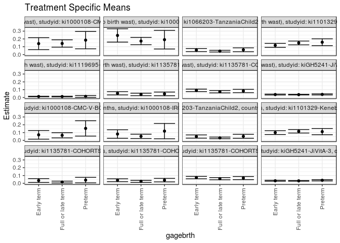

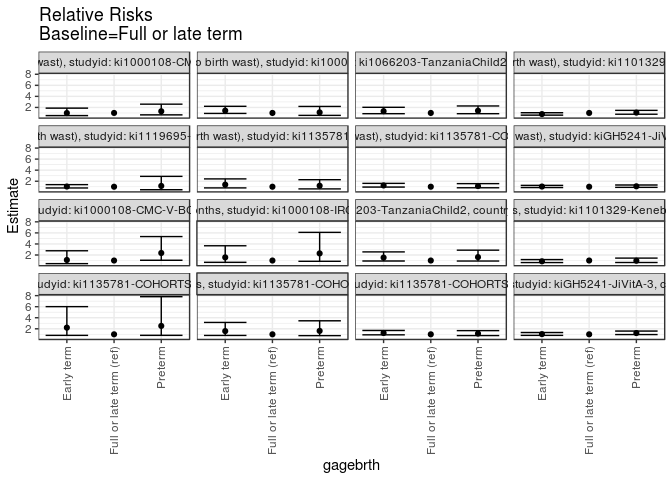

[figure not shown]

[figure not shown]

## Results Table

### Parameter: TSM

| agecat | studyid | country | intervention_level | baseline_level | estimate | ci_lower | ci_upper |
| --- | --- | --- | --- | --- | --- | --- | --- |
| 0-24 months (no birth wast) | ki1000108-CMC-V-BCS-2002 | INDIA | Full or late term | NA | 0.1419347 | 0.0947659 | 0.1891034 |
| 0-24 months (no birth wast) | ki1000108-CMC-V-BCS-2002 | INDIA | Preterm | NA | 0.1847022 | 0.0735732 | 0.2958312 |
| 0-24 months (no birth wast) | ki1000108-CMC-V-BCS-2002 | INDIA | Early term | NA | 0.1400065 | 0.0636634 | 0.2163496 |
| 0-24 months (no birth wast) | ki1000108-IRC | INDIA | Full or late term | NA | 0.1726908 | 0.1256823 | 0.2196992 |
| 0-24 months (no birth wast) | ki1000108-IRC | INDIA | Preterm | NA | 0.1904762 | 0.0715664 | 0.3093860 |
| 0-24 months (no birth wast) | ki1000108-IRC | INDIA | Early term | NA | 0.2448980 | 0.1596489 | 0.3301470 |
| 0-24 months (no birth wast) | ki1066203-TanzaniaChild2 | TANZANIA, UNITED REPUBLIC OF | Full or late term | NA | 0.0435584 | 0.0327848 | 0.0543320 |
| 0-24 months (no birth wast) | ki1066203-TanzaniaChild2 | TANZANIA, UNITED REPUBLIC OF | Preterm | NA | 0.0609045 | 0.0358371 | 0.0859718 |
| 0-24 months (no birth wast) | ki1066203-TanzaniaChild2 | TANZANIA, UNITED REPUBLIC OF | Early term | NA | 0.0575040 | 0.0375915 | 0.0774164 |
| 0-24 months (no birth wast) | ki1101329-Keneba | GAMBIA | Full or late term | NA | 0.1487554 | 0.1245548 | 0.1729560 |
| 0-24 months (no birth wast) | ki1101329-Keneba | GAMBIA | Preterm | NA | 0.1576419 | 0.1134745 | 0.2018093 |
| 0-24 months (no birth wast) | ki1101329-Keneba | GAMBIA | Early term | NA | 0.1179522 | 0.0923278 | 0.1435766 |
| 0-24 months (no birth wast) | ki1119695-PROBIT | BELARUS | Full or late term | NA | 0.0118316 | 0.0074560 | 0.0162072 |
| 0-24 months (no birth wast) | ki1119695-PROBIT | BELARUS | Preterm | NA | 0.0135364 | 0.0013326 | 0.0257401 |
| 0-24 months (no birth wast) | ki1119695-PROBIT | BELARUS | Early term | NA | 0.0122635 | 0.0085220 | 0.0160051 |
| 0-24 months (no birth wast) | ki1135781-COHORTS | INDIA | Full or late term | NA | 0.0390927 | 0.0231875 | 0.0549978 |
| 0-24 months (no birth wast) | ki1135781-COHORTS | INDIA | Preterm | NA | 0.0459994 | 0.0222110 | 0.0697879 |
| 0-24 months (no birth wast) | ki1135781-COHORTS | INDIA | Early term | NA | 0.0538456 | 0.0329478 | 0.0747435 |
| 0-24 months (no birth wast) | ki1135781-COHORTS | PHILIPPINES | Full or late term | NA | 0.0739783 | 0.0589572 | 0.0889995 |
| 0-24 months (no birth wast) | ki1135781-COHORTS | PHILIPPINES | Preterm | NA | 0.0831188 | 0.0617709 | 0.1044667 |
| 0-24 months (no birth wast) | ki1135781-COHORTS | PHILIPPINES | Early term | NA | 0.0911111 | 0.0749568 | 0.1072654 |
| 0-24 months (no birth wast) | kiGH5241-JiVitA-3 | BANGLADESH | Full or late term | NA | 0.0364178 | 0.0324137 | 0.0404218 |
| 0-24 months (no birth wast) | kiGH5241-JiVitA-3 | BANGLADESH | Preterm | NA | 0.0392907 | 0.0324814 | 0.0460999 |
| 0-24 months (no birth wast) | kiGH5241-JiVitA-3 | BANGLADESH | Early term | NA | 0.0376874 | 0.0318403 | 0.0435346 |
| 6-24 months | ki1000108-CMC-V-BCS-2002 | INDIA | Full or late term | NA | 0.0651163 | 0.0320891 | 0.0981435 |
| 6-24 months | ki1000108-CMC-V-BCS-2002 | INDIA | Preterm | NA | 0.1538462 | 0.0556411 | 0.2520512 |
| 6-24 months | ki1000108-CMC-V-BCS-2002 | INDIA | Early term | NA | 0.0714286 | 0.0162753 | 0.1265819 |
| 6-24 months | ki1000108-IRC | INDIA | Full or late term | NA | 0.0520000 | 0.0244424 | 0.0795576 |
| 6-24 months | ki1000108-IRC | INDIA | Preterm | NA | 0.1190476 | 0.0209818 | 0.2171134 |
| 6-24 months | ki1000108-IRC | INDIA | Early term | NA | 0.0816327 | 0.0273535 | 0.1359118 |
| 6-24 months | ki1066203-TanzaniaChild2 | TANZANIA, UNITED REPUBLIC OF | Full or late term | NA | 0.0325623 | 0.0223521 | 0.0427725 |
| 6-24 months | ki1066203-TanzaniaChild2 | TANZANIA, UNITED REPUBLIC OF | Preterm | NA | 0.0526934 | 0.0273241 | 0.0780628 |
| 6-24 months | ki1066203-TanzaniaChild2 | TANZANIA, UNITED REPUBLIC OF | Early term | NA | 0.0498254 | 0.0294392 | 0.0702116 |
| 6-24 months | ki1101329-Keneba | GAMBIA | Full or late term | NA | 0.1167801 | 0.0945913 | 0.1389689 |
| 6-24 months | ki1101329-Keneba | GAMBIA | Preterm | NA | 0.1123762 | 0.0722845 | 0.1524679 |
| 6-24 months | ki1101329-Keneba | GAMBIA | Early term | NA | 0.0999938 | 0.0755241 | 0.1244635 |
| 6-24 months | ki1135781-COHORTS | GUATEMALA | Full or late term | NA | 0.0163934 | 0.0043414 | 0.0284455 |
| 6-24 months | ki1135781-COHORTS | GUATEMALA | Preterm | NA | 0.0413223 | 0.0058355 | 0.0768091 |
| 6-24 months | ki1135781-COHORTS | GUATEMALA | Early term | NA | 0.0361991 | 0.0115570 | 0.0608412 |
| 6-24 months | ki1135781-COHORTS | INDIA | Full or late term | NA | 0.0251582 | 0.0122076 | 0.0381088 |
| 6-24 months | ki1135781-COHORTS | INDIA | Preterm | NA | 0.0407736 | 0.0182712 | 0.0632760 |
| 6-24 months | ki1135781-COHORTS | INDIA | Early term | NA | 0.0397816 | 0.0214959 | 0.0580673 |
| 6-24 months | ki1135781-COHORTS | PHILIPPINES | Full or late term | NA | 0.0594179 | 0.0452913 | 0.0735446 |
| 6-24 months | ki1135781-COHORTS | PHILIPPINES | Preterm | NA | 0.0673913 | 0.0471554 | 0.0876273 |
| 6-24 months | ki1135781-COHORTS | PHILIPPINES | Early term | NA | 0.0735151 | 0.0582823 | 0.0887479 |
| 6-24 months | kiGH5241-JiVitA-3 | BANGLADESH | Full or late term | NA | 0.0316718 | 0.0271562 | 0.0361873 |
| 6-24 months | kiGH5241-JiVitA-3 | BANGLADESH | Preterm | NA | 0.0389310 | 0.0306842 | 0.0471778 |
| 6-24 months | kiGH5241-JiVitA-3 | BANGLADESH | Early term | NA | 0.0327633 | 0.0264630 | 0.0390635 |

### Parameter: E(Y)

| agecat | studyid | country | intervention_level | baseline_level | estimate | ci_lower | ci_upper |
| --- | --- | --- | --- | --- | --- | --- | --- |
| 0-24 months (no birth wast) | ki1000108-CMC-V-BCS-2002 | INDIA | NA | NA | 0.1494253 | 0.1119149 | 0.1869357 |
| 0-24 months (no birth wast) | ki1000108-IRC | INDIA | NA | NA | 0.1928021 | 0.1535486 | 0.2320555 |
| 0-24 months (no birth wast) | ki1066203-TanzaniaChild2 | TANZANIA, UNITED REPUBLIC OF | NA | NA | 0.0495094 | 0.0405280 | 0.0584908 |
| 0-24 months (no birth wast) | ki1101329-Keneba | GAMBIA | NA | NA | 0.1389710 | 0.1224789 | 0.1554631 |
| 0-24 months (no birth wast) | ki1119695-PROBIT | BELARUS | NA | NA | 0.0120875 | 0.0084025 | 0.0157724 |
| 0-24 months (no birth wast) | ki1135781-COHORTS | INDIA | NA | NA | 0.0460967 | 0.0348859 | 0.0573074 |
| 0-24 months (no birth wast) | ki1135781-COHORTS | PHILIPPINES | NA | NA | 0.0821918 | 0.0723504 | 0.0920332 |
| 0-24 months (no birth wast) | kiGH5241-JiVitA-3 | BANGLADESH | NA | NA | 0.0374074 | 0.0343544 | 0.0404603 |
| 6-24 months | ki1000108-CMC-V-BCS-2002 | INDIA | NA | NA | 0.0797721 | 0.0513872 | 0.1081570 |
| 6-24 months | ki1000108-IRC | INDIA | NA | NA | 0.0666667 | 0.0418784 | 0.0914549 |
| 6-24 months | ki1066203-TanzaniaChild2 | TANZANIA, UNITED REPUBLIC OF | NA | NA | 0.0400633 | 0.0312360 | 0.0488905 |
| 6-24 months | ki1101329-Keneba | GAMBIA | NA | NA | 0.1107034 | 0.0954900 | 0.1259167 |
| 6-24 months | ki1135781-COHORTS | GUATEMALA | NA | NA | 0.0260078 | 0.0147515 | 0.0372641 |
| 6-24 months | ki1135781-COHORTS | INDIA | NA | NA | 0.0339111 | 0.0241689 | 0.0436532 |
| 6-24 months | ki1135781-COHORTS | PHILIPPINES | NA | NA | 0.0667384 | 0.0574713 | 0.0760056 |
| 6-24 months | kiGH5241-JiVitA-3 | BANGLADESH | NA | NA | 0.0335958 | 0.0302945 | 0.0368970 |

### Parameter: RR

| agecat | studyid | country | intervention_level | baseline_level | estimate | ci_lower | ci_upper |
| --- | --- | --- | --- | --- | --- | --- | --- |
| 0-24 months (no birth wast) | ki1000108-CMC-V-BCS-2002 | INDIA | Full or late term | Full or late term | 1.0000000 | 1.0000000 | 1.000000 |
| 0-24 months (no birth wast) | ki1000108-CMC-V-BCS-2002 | INDIA | Preterm | Full or late term | 1.3013186 | 0.6538721 | 2.589849 |
| 0-24 months (no birth wast) | ki1000108-CMC-V-BCS-2002 | INDIA | Early term | Full or late term | 0.9864150 | 0.5203714 | 1.869846 |
| 0-24 months (no birth wast) | ki1000108-IRC | INDIA | Full or late term | Full or late term | 1.0000000 | 1.0000000 | 1.000000 |
| 0-24 months (no birth wast) | ki1000108-IRC | INDIA | Preterm | Full or late term | 1.1029900 | 0.5582108 | 2.179440 |
| 0-24 months (no birth wast) | ki1000108-IRC | INDIA | Early term | Full or late term | 1.4181300 | 0.9115965 | 2.206122 |
| 0-24 months (no birth wast) | ki1066203-TanzaniaChild2 | TANZANIA, UNITED REPUBLIC OF | Full or late term | Full or late term | 1.0000000 | 1.0000000 | 1.000000 |
| 0-24 months (no birth wast) | ki1066203-TanzaniaChild2 | TANZANIA, UNITED REPUBLIC OF | Preterm | Full or late term | 1.3982259 | 0.8649977 | 2.260163 |
| 0-24 months (no birth wast) | ki1066203-TanzaniaChild2 | TANZANIA, UNITED REPUBLIC OF | Early term | Full or late term | 1.3201581 | 0.8625666 | 2.020502 |
| 0-24 months (no birth wast) | ki1101329-Keneba | GAMBIA | Full or late term | Full or late term | 1.0000000 | 1.0000000 | 1.000000 |
| 0-24 months (no birth wast) | ki1101329-Keneba | GAMBIA | Preterm | Full or late term | 1.0597390 | 0.7665752 | 1.465019 |
| 0-24 months (no birth wast) | ki1101329-Keneba | GAMBIA | Early term | Full or late term | 0.7929273 | 0.6049438 | 1.039326 |
| 0-24 months (no birth wast) | ki1119695-PROBIT | BELARUS | Full or late term | Full or late term | 1.0000000 | 1.0000000 | 1.000000 |
| 0-24 months (no birth wast) | ki1119695-PROBIT | BELARUS | Preterm | Full or late term | 1.1440894 | 0.4554164 | 2.874162 |
| 0-24 months (no birth wast) | ki1119695-PROBIT | BELARUS | Early term | Full or late term | 1.0365092 | 0.7781711 | 1.380611 |
| 0-24 months (no birth wast) | ki1135781-COHORTS | INDIA | Full or late term | Full or late term | 1.0000000 | 1.0000000 | 1.000000 |
| 0-24 months (no birth wast) | ki1135781-COHORTS | INDIA | Preterm | Full or late term | 1.1766776 | 0.6094084 | 2.271991 |
| 0-24 months (no birth wast) | ki1135781-COHORTS | INDIA | Early term | Full or late term | 1.3773851 | 0.7849406 | 2.416985 |
| 0-24 months (no birth wast) | ki1135781-COHORTS | PHILIPPINES | Full or late term | Full or late term | 1.0000000 | 1.0000000 | 1.000000 |
| 0-24 months (no birth wast) | ki1135781-COHORTS | PHILIPPINES | Preterm | Full or late term | 1.1235562 | 0.8098247 | 1.558829 |
| 0-24 months (no birth wast) | ki1135781-COHORTS | PHILIPPINES | Early term | Full or late term | 1.2315919 | 0.9408221 | 1.612227 |
| 0-24 months (no birth wast) | kiGH5241-JiVitA-3 | BANGLADESH | Full or late term | Full or late term | 1.0000000 | 1.0000000 | 1.000000 |
| 0-24 months (no birth wast) | kiGH5241-JiVitA-3 | BANGLADESH | Preterm | Full or late term | 1.0788862 | 0.8846151 | 1.315821 |
| 0-24 months (no birth wast) | kiGH5241-JiVitA-3 | BANGLADESH | Early term | Full or late term | 1.0348636 | 0.8574942 | 1.248921 |
| 6-24 months | ki1000108-CMC-V-BCS-2002 | INDIA | Full or late term | Full or late term | 1.0000000 | 1.0000000 | 1.000000 |
| 6-24 months | ki1000108-CMC-V-BCS-2002 | INDIA | Preterm | Full or late term | 2.3626374 | 1.0454758 | 5.339249 |
| 6-24 months | ki1000108-CMC-V-BCS-2002 | INDIA | Early term | Full or late term | 1.0969388 | 0.4354790 | 2.763106 |
| 6-24 months | ki1000108-IRC | INDIA | Full or late term | Full or late term | 1.0000000 | 1.0000000 | 1.000000 |
| 6-24 months | ki1000108-IRC | INDIA | Preterm | Full or late term | 2.2893773 | 0.8596588 | 6.096894 |
| 6-24 months | ki1000108-IRC | INDIA | Early term | Full or late term | 1.5698587 | 0.6707962 | 3.673927 |
| 6-24 months | ki1066203-TanzaniaChild2 | TANZANIA, UNITED REPUBLIC OF | Full or late term | Full or late term | 1.0000000 | 1.0000000 | 1.000000 |
| 6-24 months | ki1066203-TanzaniaChild2 | TANZANIA, UNITED REPUBLIC OF | Preterm | Full or late term | 1.6182345 | 0.9108426 | 2.875011 |
| 6-24 months | ki1066203-TanzaniaChild2 | TANZANIA, UNITED REPUBLIC OF | Early term | Full or late term | 1.5301545 | 0.9137185 | 2.562466 |
| 6-24 months | ki1101329-Keneba | GAMBIA | Full or late term | Full or late term | 1.0000000 | 1.0000000 | 1.000000 |
| 6-24 months | ki1101329-Keneba | GAMBIA | Preterm | Full or late term | 0.9622890 | 0.6423565 | 1.441567 |
| 6-24 months | ki1101329-Keneba | GAMBIA | Early term | Full or late term | 0.8562573 | 0.6282138 | 1.167082 |
| 6-24 months | ki1135781-COHORTS | GUATEMALA | Full or late term | Full or late term | 1.0000000 | 1.0000000 | 1.000000 |
| 6-24 months | ki1135781-COHORTS | GUATEMALA | Preterm | Full or late term | 2.5206609 | 0.8138650 | 7.806862 |
| 6-24 months | ki1135781-COHORTS | GUATEMALA | Early term | Full or late term | 2.2081446 | 0.8107545 | 6.014031 |
| 6-24 months | ki1135781-COHORTS | INDIA | Full or late term | Full or late term | 1.0000000 | 1.0000000 | 1.000000 |
| 6-24 months | ki1135781-COHORTS | INDIA | Preterm | Full or late term | 1.6206862 | 0.7626595 | 3.444032 |
| 6-24 months | ki1135781-COHORTS | INDIA | Early term | Full or late term | 1.5812573 | 0.7937118 | 3.150230 |
| 6-24 months | ki1135781-COHORTS | PHILIPPINES | Full or late term | Full or late term | 1.0000000 | 1.0000000 | 1.000000 |
| 6-24 months | ki1135781-COHORTS | PHILIPPINES | Preterm | Full or late term | 1.1341924 | 0.7735584 | 1.662955 |
| 6-24 months | ki1135781-COHORTS | PHILIPPINES | Early term | Full or late term | 1.2372546 | 0.9029297 | 1.695369 |
| 6-24 months | kiGH5241-JiVitA-3 | BANGLADESH | Full or late term | Full or late term | 1.0000000 | 1.0000000 | 1.000000 |
| 6-24 months | kiGH5241-JiVitA-3 | BANGLADESH | Preterm | Full or late term | 1.2292035 | 0.9517212 | 1.587588 |
| 6-24 months | kiGH5241-JiVitA-3 | BANGLADESH | Early term | Full or late term | 1.0344634 | 0.8104040 | 1.320470 |

### Parameter: PAR

| agecat | studyid | country | intervention_level | baseline_level | estimate | ci_lower | ci_upper |
| --- | --- | --- | --- | --- | --- | --- | --- |
| 0-24 months (no birth wast) | ki1000108-CMC-V-BCS-2002 | INDIA | Full or late term | NA | 0.0074906 | -0.0230570 | 0.0380383 |
| 0-24 months (no birth wast) | ki1000108-IRC | INDIA | Full or late term | NA | 0.0201113 | -0.0102472 | 0.0504698 |
| 0-24 months (no birth wast) | ki1066203-TanzaniaChild2 | TANZANIA, UNITED REPUBLIC OF | Full or late term | NA | 0.0059510 | -0.0014091 | 0.0133111 |
| 0-24 months (no birth wast) | ki1101329-Keneba | GAMBIA | Full or late term | NA | -0.0097844 | -0.0263603 | 0.0067915 |
| 0-24 months (no birth wast) | ki1119695-PROBIT | BELARUS | Full or late term | NA | 0.0002559 | -0.0014408 | 0.0019526 |
| 0-24 months (no birth wast) | ki1135781-COHORTS | INDIA | Full or late term | NA | 0.0070040 | -0.0056832 | 0.0196912 |
| 0-24 months (no birth wast) | ki1135781-COHORTS | PHILIPPINES | Full or late term | NA | 0.0082135 | -0.0039408 | 0.0203677 |
| 0-24 months (no birth wast) | kiGH5241-JiVitA-3 | BANGLADESH | Full or late term | NA | 0.0009896 | -0.0018014 | 0.0037805 |
| 6-24 months | ki1000108-CMC-V-BCS-2002 | INDIA | Full or late term | NA | 0.0146558 | -0.0090126 | 0.0383242 |
| 6-24 months | ki1000108-IRC | INDIA | Full or late term | NA | 0.0146667 | -0.0053399 | 0.0346732 |
| 6-24 months | ki1066203-TanzaniaChild2 | TANZANIA, UNITED REPUBLIC OF | Full or late term | NA | 0.0075010 | 0.0001251 | 0.0148768 |
| 6-24 months | ki1101329-Keneba | GAMBIA | Full or late term | NA | -0.0060767 | -0.0213748 | 0.0092214 |
| 6-24 months | ki1135781-COHORTS | GUATEMALA | Full or late term | NA | 0.0096144 | -0.0009047 | 0.0201334 |
| 6-24 months | ki1135781-COHORTS | INDIA | Full or late term | NA | 0.0087529 | -0.0020180 | 0.0195237 |
| 6-24 months | ki1135781-COHORTS | PHILIPPINES | Full or late term | NA | 0.0073205 | -0.0040641 | 0.0187051 |
| 6-24 months | kiGH5241-JiVitA-3 | BANGLADESH | Full or late term | NA | 0.0019240 | -0.0013651 | 0.0052131 |

### Parameter: PAF

| agecat | studyid | country | intervention_level | baseline_level | estimate | ci_lower | ci_upper |
| --- | --- | --- | --- | --- | --- | --- | --- |
| 0-24 months (no birth wast) | ki1000108-CMC-V-BCS-2002 | INDIA | Full or late term | NA | 0.0501296 | -0.1776664 | 0.2338630 |
| 0-24 months (no birth wast) | ki1000108-IRC | INDIA | Full or late term | NA | 0.1043106 | -0.0668583 | 0.2480168 |
| 0-24 months (no birth wast) | ki1066203-TanzaniaChild2 | TANZANIA, UNITED REPUBLIC OF | Full or late term | NA | 0.1201992 | -0.0399802 | 0.2557075 |
| 0-24 months (no birth wast) | ki1101329-Keneba | GAMBIA | Full or late term | NA | -0.0704059 | -0.1962429 | 0.0421940 |
| 0-24 months (no birth wast) | ki1119695-PROBIT | BELARUS | Full or late term | NA | 0.0211692 | -0.1315283 | 0.1532605 |
| 0-24 months (no birth wast) | ki1135781-COHORTS | INDIA | Full or late term | NA | 0.1519417 | -0.1705764 | 0.3855994 |
| 0-24 months (no birth wast) | ki1135781-COHORTS | PHILIPPINES | Full or late term | NA | 0.0999304 | -0.0602405 | 0.2359041 |
| 0-24 months (no birth wast) | kiGH5241-JiVitA-3 | BANGLADESH | Full or late term | NA | 0.0264541 | -0.0509752 | 0.0981789 |
| 6-24 months | ki1000108-CMC-V-BCS-2002 | INDIA | Full or late term | NA | 0.1837209 | -0.1651221 | 0.4281187 |
| 6-24 months | ki1000108-IRC | INDIA | Full or late term | NA | 0.2200000 | -0.1312945 | 0.4622090 |
| 6-24 months | ki1066203-TanzaniaChild2 | TANZANIA, UNITED REPUBLIC OF | Full or late term | NA | 0.1872278 | -0.0139894 | 0.3485152 |
| 6-24 months | ki1101329-Keneba | GAMBIA | Full or late term | NA | -0.0548920 | -0.2022802 | 0.0744278 |
| 6-24 months | ki1135781-COHORTS | GUATEMALA | Full or late term | NA | 0.3696721 | -0.1384210 | 0.6509962 |
| 6-24 months | ki1135781-COHORTS | INDIA | Full or late term | NA | 0.2581120 | -0.1281325 | 0.5121160 |
| 6-24 months | ki1135781-COHORTS | PHILIPPINES | Full or late term | NA | 0.1096897 | -0.0777642 | 0.2645400 |
| 6-24 months | kiGH5241-JiVitA-3 | BANGLADESH | Full or late term | NA | 0.0572694 | -0.0456956 | 0.1500960 |